# Electricity Demand for Heating and Cooling in New Zealand

Test data

Ben Anderson (ben.anderson@otago.ac.nz, `@dataknut`) & Emily Jiang

Last run at: 2019-03-22 10:11:09

# 1 Setup

This is where we do setup stuff like attaching libraries etc.

```r
# Set start time ----
startTime <- proc.time()

# What are we running on?
sysInfo <- Sys.info()
myParams <- list()
myParams$sysName <- sysInfo[[1]]
myParams$nodeName <- sysInfo[[4]]
myParams$userName <- sysInfo[[7]]

if (myParams$userName == "ben") {
    # BA laptop myParams$dPath <- path.expand('/Volumes/hum-csafe/Research
    # Projects/GREEN Grid/Self_contained_Projects/2018_coolingEmily/archive/') #
    # HCS - requires VPN/on-campus connection
    myParams$dPath <- path.expand("~/Data/NZ_GREENGrid/safe/emilyJiang/")  # copy of data on HCS
} else {
    myParams$dPath <- "Z:/Research Projects/GREEN Grid/Self_contained_Projects/2018_coolingEmily/archive/"  # <- windoze
}

# Functions ----

# Emily's libraries and functions
source("../R/libraries.R")  # Emily's recommended libraries
source("../R/functions.R")  # Emily's functions

# Local libraries ----
library(kableExtra)  # for fancy tables
# any extras?
```

# 2 Load final data

## 2.1 Heat pumps

First we load Emily’s processed heat pump data and run some basic tests.

```r
df <- paste0(myParams$dPath, "allHouseholds_hourly.csv.gz")

message("Loading", df)
```

```
## Loading/Users/ben/Data/NZ_GREENGrid/safe/emilyJiang/allHouseholds_hourly.csv.gz
```

```r
hpDT <- data.table::fread(df)

# drop V1 (purpose?)
hpDT$V1 <- NULL

# location is constant by id so we could just create a table and drop that
# columhn too but...

# fix the date - remember it's stored as UTC
hpDT <- hpDT[, `:=`(r_dateTimeChar, r_dateTime)]
hpDT <- hpDT[, `:=`(r_dateTime, lubridate::as_datetime(r_dateTime))]
hpDT <- hpDT[, `:=`(r_dateTimeLocal, lubridate::with_tz(r_dateTime, tzone = "Pacific/Auckland"))]  # convert to local time from UTC

hpDT <- hpDT[, `:=`(hms, hms::as.hms(r_dateTimeLocal))]  # useful for plots and for checking we have the right timezone!

hpDT <- GREENGridData::addNZSeason(hpDT, r_dateTime = r_dateTimeLocal)
```

If any of the r_dateTimes failed to parse they will have the local time set to NA so we can see what happened (if anything) in Table 2.1. If there are no rows in this table then all r_dateTimes parsed.

```r
kableExtra::kable(head(hpDT[is.na(r_dateTime)], 10), caption = "First 10 rows of Heat Pump data where r_dateTime failed to parse (could be none at all)") %>%
    kable_styling()
```

Table 2.1: First 10 rows of Heat Pump data where r_dateTime failed to parse (could be none at all)

| r_dateTime | powerW | circuit | id | location | r_dateTimeChar | r_dateTimeLocal | hms | season |
| --- | --- | --- | --- | --- | --- | --- | --- | --- |

Table 2.2 shows the first 10 rows of slighty processed data. Note that local time ias set to NZ time while the original r_dateTime is in UTC. This is important for linking the temperature data correctly!

```r
kableExtra::kable(head(hpDT, 10), caption = "First 10 rows of (slightly) processed Heat Pump data") %>%
    kable_styling()
```

Table 2.2: First 10 rows of (slightly) processed Heat Pump data

| r_dateTime | powerW | circuit | id | location | r_dateTimeChar | r_dateTimeLocal | hms | season |
| --- | --- | --- | --- | --- | --- | --- | --- | --- |
| 2015-03-26 04:00:00 | 0.00000 | Heat Pump$4204 | rf_31 | 15876 | 2015-03-26 04:00:00 | 2015-03-26 17:00:00 | 17:00:00 | Autumn |
| 2015-03-26 05:00:00 | 33.68717 | Heat Pump$4204 | rf_31 | 15876 | 2015-03-26 05:00:00 | 2015-03-26 18:00:00 | 18:00:00 | Autumn |
| 2015-03-26 06:00:00 | 0.00000 | Heat Pump$4204 | rf_31 | 15876 | 2015-03-26 06:00:00 | 2015-03-26 19:00:00 | 19:00:00 | Autumn |
| 2015-03-26 07:00:00 | 0.00000 | Heat Pump$4204 | rf_31 | 15876 | 2015-03-26 07:00:00 | 2015-03-26 20:00:00 | 20:00:00 | Autumn |
| 2015-03-26 08:00:00 | 0.00000 | Heat Pump$4204 | rf_31 | 15876 | 2015-03-26 08:00:00 | 2015-03-26 21:00:00 | 21:00:00 | Autumn |
| 2015-03-26 09:00:00 | 0.00000 | Heat Pump$4204 | rf_31 | 15876 | 2015-03-26 09:00:00 | 2015-03-26 22:00:00 | 22:00:00 | Autumn |
| 2015-03-26 10:00:00 | 0.00000 | Heat Pump$4204 | rf_31 | 15876 | 2015-03-26 10:00:00 | 2015-03-26 23:00:00 | 23:00:00 | Autumn |
| 2015-03-26 11:00:00 | 0.00000 | Heat Pump$4204 | rf_31 | 15876 | 2015-03-26 11:00:00 | 2015-03-27 00:00:00 | 00:00:00 | Autumn |
| 2015-03-26 12:00:00 | 0.00000 | Heat Pump$4204 | rf_31 | 15876 | 2015-03-26 12:00:00 | 2015-03-27 01:00:00 | 01:00:00 | Autumn |
| 2015-03-26 13:00:00 | 0.00000 | Heat Pump$4204 | rf_31 | 15876 | 2015-03-26 13:00:00 | 2015-03-27 02:00:00 | 02:00:00 | Autumn |

The next table gives a summary of the heat pump data after limited processing (no cleaning) while Table 2.3 gives a list of all circuit labels seen - as a check on what we think they are measuring.

```r
skimr::skim(hpDT)
```

```
## Skim summary statistics
##  n obs: 441379
##  n variables: 9
##
## ── Variable type:character ───────────────────────────────────────────────────────────────────────────────────────────────────────────
##        variable missing complete      n min max empty n_unique
##         circuit       0   441379 441379  14  33     0       20
##              id       0   441379 441379   5   6     0       18
##  r_dateTimeChar       0   441379 441379  19  19     0    36583
##
## ── Variable type:difftime ────────────────────────────────────────────────────────────────────────────────────────────────────────────
##  variable missing complete      n    min        max   median n_unique
##       hms       0   441379 441379 0 secs 82800 secs 12:00:00       24
##
## ── Variable type:factor ──────────────────────────────────────────────────────────────────────────────────────────────────────────────
##  variable missing complete      n n_unique
##    season       0   441379 441379        4
##                                         top_counts ordered
##  Win: 122946, Aut: 111768, Spr: 107705, Sum: 98960   FALSE
##
## ── Variable type:integer ─────────────────────────────────────────────────────────────────────────────────────────────────────────────
##  variable missing complete      n     mean      sd    p0   p25   p50   p75
##  location       0   441379 441379 19944.32 3997.39 15876 15876 23872 23872
##   p100     hist
##  23872 ▇▁▁▁▁▁▁▇
##
## ── Variable type:numeric ─────────────────────────────────────────────────────────────────────────────────────────────────────────────
##  variable missing complete      n  mean     sd p0 p25 p50   p75    p100
##    powerW       0   441379 441379 95.47 271.51  0   0   0 19.02 4342.47
##      hist
##  ▇▁▁▁▁▁▁▁
##
## ── Variable type:POSIXct ─────────────────────────────────────────────────────────────────────────────────────────────────────────────
##         variable missing complete      n        min        max     median
##       r_dateTime       0   441379 441379 2014-05-28 2018-08-01 2016-04-08
##  r_dateTimeLocal       0   441379 441379 2014-05-29 2018-08-01 2016-04-09
##  n_unique
##     36583
##     36583
```

Emily’s analysis excludes the following circuits:

- `Downstairs (inc 1 Heat Pump)$2212`
- `Bedroom & Lounge Heat Pumps$2741` - why exclude this one?
- `Theatre Heat Pump$2740`

How many of them are there?

```r
# flag the circuits we don't want
hpDT <- hpDT[, includeCircuit := ifelse(circuit == "Downstairs (inc 1 Heat Pump)$2212" |
                                          circuit == "Bedroom & Lounge Heat Pumps$2741" | # why exclude this one?
                                          circuit == "Theatre Heat Pump$2740",
                                        0, # exclude
                                        1)] # sets all others to 1

t <- table(hpDT$circuit, hpDT$includeCircuit)

kableExtra::kable(t, caption = "Counts of circuit labels for those we exclude (0) and those we include (1)") %>%
  kable_styling()
```

Table 2.3: Counts of circuit labels for those we exclude (0) and those we include (1)

|  | 0 | 1 |
| --- | --- | --- |
| Bedroom & Lounge Heat Pumps$2741 | 35181 | 0 |
| Downstairs (inc 1 Heat Pump)$2212 | 18752 | 0 |
| Heat Pump$2092 | 0 | 25831 |
| Heat Pump$2148 | 0 | 16012 |
| Heat Pump$2598 | 0 | 30378 |
| Heat Pump$2758 | 0 | 11800 |
| Heat Pump$2826 | 0 | 15161 |
| Heat Pump$4124 | 0 | 13045 |
| Heat Pump$4130 | 0 | 16273 |
| Heat Pump$4134 | 0 | 29398 |
| Heat Pump$4150 | 0 | 26788 |
| Heat Pump$4154 | 0 | 29379 |
| Heat Pump$4160 | 0 | 13669 |
| Heat Pump$4175 | 0 | 14779 |
| Heat Pump$4190 | 0 | 22913 |
| Heat Pump$4196 | 0 | 9023 |
| Heat Pump$4204 | 0 | 29351 |
| Heat Pump$4223 | 0 | 12190 |
| Theatre Heat Pump$2740 | 35181 | 0 |
| Upstairs Heat Pumps$2211 | 0 | 36275 |

Table 2.4 gives summary statistics for heat pump demand for all circuits and all households (id).

```r
t <- hpDT[, .(nObs = .N, meanW = mean(powerW), minW = min(powerW), maxW = max(powerW)),
    keyby = .(id, circuit, location)]

kableExtra::kable(t, caption = "Heat pump statistics by household") %>% kable_styling()
```

Table 2.4: Heat pump statistics by household

| id | circuit | location | nObs | meanW | minW | maxW |
| --- | --- | --- | --- | --- | --- | --- |
| rf_08 | Heat Pump$2092 | 23872 | 25831 | 67.119591 | 0 | 1692.450 |
| rf_10 | Heat Pump$2598 | 23872 | 30378 | 48.317166 | 0 | 2245.535 |
| rf_13 | Downstairs (inc 1 Heat Pump)$2212 | 23872 | 18752 | 276.478907 | 0 | 2919.731 |
| rf_13 | Upstairs Heat Pumps$2211 | 23872 | 36275 | 148.184983 | 0 | 2692.076 |
| rf_17a | Heat Pump$2148 | 23872 | 16012 | 25.986817 | 0 | 3145.554 |
| rf_19 | Bedroom & Lounge Heat Pumps$2741 | 23872 | 35181 | 90.488668 | 0 | 2167.546 |
| rf_19 | Theatre Heat Pump$2740 | 23872 | 35181 | 3.030243 | 0 | 800.684 |
| rf_25 | Heat Pump$2758 | 23872 | 11800 | 89.182960 | 0 | 1726.893 |
| rf_27 | Heat Pump$2826 | 23872 | 15161 | 138.368410 | 0 | 2382.799 |
| rf_31 | Heat Pump$4204 | 15876 | 29351 | 127.532600 | 0 | 2109.801 |
| rf_32 | Heat Pump$4196 | 15876 | 9023 | 67.796572 | 0 | 1860.604 |
| rf_34 | Heat Pump$4223 | 15876 | 12190 | 196.538713 | 0 | 4342.474 |
| rf_35 | Heat Pump$4124 | 15876 | 13045 | 58.915105 | 0 | 1127.889 |
| rf_36 | Heat Pump$4150 | 15876 | 26788 | 104.854347 | 0 | 2365.296 |
| rf_37 | Heat Pump$4134 | 15876 | 29398 | 49.805530 | 0 | 1752.853 |
| rf_38 | Heat Pump$4175 | 15876 | 14779 | 247.926515 | 0 | 2431.999 |
| rf_41 | Heat Pump$4190 | 15876 | 22913 | 51.088287 | 0 | 3528.475 |
| rf_42 | Heat Pump$4130 | 15876 | 16273 | 44.588199 | 0 | 2113.905 |
| rf_44 | Heat Pump$4154 | 15876 | 29379 | 97.935001 | 0 | 1998.174 |
| rf_45 | Heat Pump$4160 | 15876 | 13669 | 94.366494 | 0 | 2284.892 |

Table 2.5 gives summary statistics for heat pump demand for all circuits in each location.

```r
t <- hpDT[, .(nHouseholds = uniqueN(id), nObs = .N, meanW = mean(powerW), minW = min(powerW),
    maxW = max(powerW)), keyby = .(location, season)]

kableExtra::kable(t, caption = "Heat pump statistics by household") %>% kable_styling()
```

Table 2.5: Heat pump statistics by household

| location | season | nHouseholds | nObs | meanW | minW | maxW |
| --- | --- | --- | --- | --- | --- | --- |
| 15876 | Spring | 11 | 50789 | 52.30310 | 0 | 3598.496 |
| 15876 | Summer | 11 | 44567 | 11.23806 | 0 | 3653.164 |
| 15876 | Autumn | 11 | 59071 | 58.86289 | 0 | 3376.472 |
| 15876 | Winter | 11 | 62381 | 238.62007 | 0 | 4342.474 |
| 23872 | Spring | 7 | 56916 | 70.98425 | 0 | 2635.756 |
| 23872 | Summer | 7 | 54393 | 35.20986 | 0 | 2382.799 |
| 23872 | Autumn | 7 | 52697 | 54.59329 | 0 | 2451.487 |
| 23872 | Winter | 7 | 60565 | 194.59470 | 0 | 3145.554 |

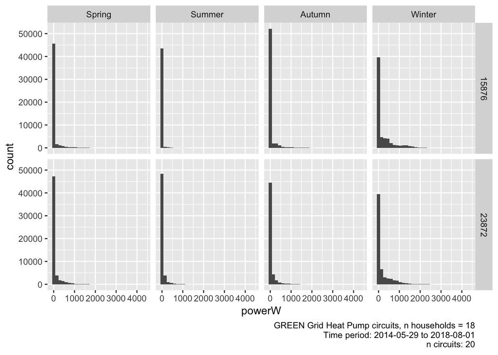

Figure 2.1: Histogram mean hourly power demand for Heat Pumps by season and location

```r
hpCap <- paste0("GREEN Grid Heat Pump circuits, n households = ", uniqueN(hpDT$id),
    "\n Time period: ", min(lubridate::date(hpDT$r_dateTimeLocal)), " to ",
    max(lubridate::date(hpDT$r_dateTimeLocal)))

ggplot2::ggplot(hpDT, aes(x = powerW)) + geom_histogram() + facet_grid(location ~
    season) + labs(caption = paste0(hpCap, "\n n circuits: ", uniqueN(hpDT$circuit)))
```

Figure 2.2 shows same plot but only for power > 40 W and only for the circuits we want to include. Does this look right?

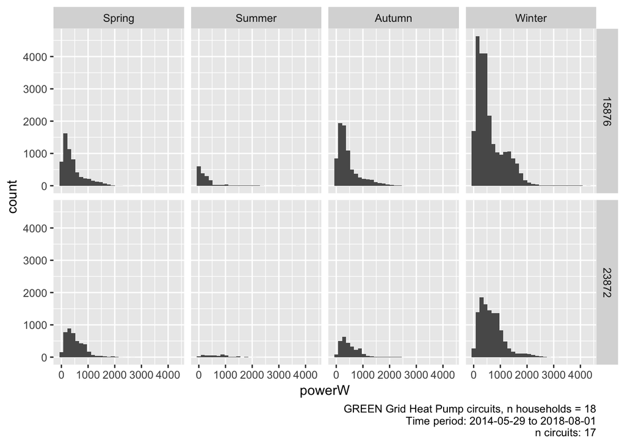

Figure 2.2: Histogram mean hourly power demand for Heat Pumps by season and location

```r
dt <- hpDT[powerW > 40 & includeCircuit == 1]
ggplot2::ggplot(dt, aes(x = powerW)) + geom_histogram() + facet_grid(location ~
    season) + labs(caption = paste0(hpCap, "\n n circuits: ", uniqueN(dt$circuit)))
```

Figure 2.3 shows the mean heat pump demand by time of day by season for the circuits we want to include. Does this look right?

Figure 2.3 is important because:

- we converted the incoming UTC dateTime to local (NZT) time -> `r_dateTimeLocal`
- we then created a hh:mm variable from `r_dateTimeLocal` and used that to make this plot
- so if this looks like the right shape for Heat Pump demand then we have made the correct assumptions about the incoming `r_dateTime`

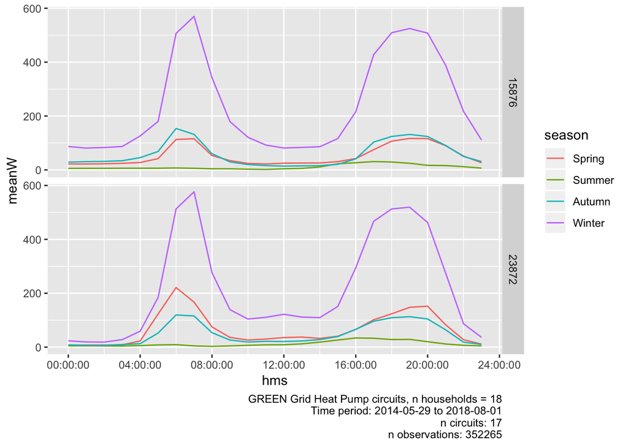

Figure 2.3: Line plot of mean power demand for Heat Pumps by season and location

```r
dt <- hpDT[includeCircuit == 1]

plotDT <- dt[, .(meanW = mean(powerW)), keyby = .(hms, season, location)]

ggplot2::ggplot(plotDT, aes(x = hms, y = meanW, colour = season)) + geom_line() +
    facet_grid(location ~ .) + labs(caption = paste0(hpCap, "\n n circuits: ",
    uniqueN(dt$circuit), "\n n observations: ", nrow(dt[!is.na(powerW)])))
```

Are we seeing some cooling in summer?

We can repeat this plot including only powerW values > 40 W (Figure 2.4). This shows the level of demand *when they are on*. This plot shows some distinct signs of heat pump use in early evenings in summer producing a slightly earlier ‘peak’ than is the case for winter heating. It has to be said however that the plots are quite messy, no doubt due to the small numbers involved.

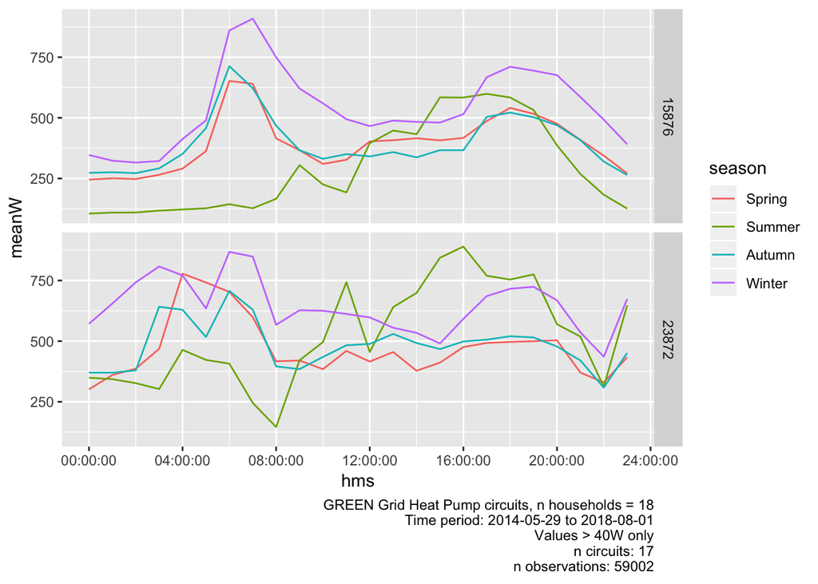

Figure 2.4: Line plot of mean power demand for Heat Pumps by season and location where power > 40W

```r
dt <- hpDT[powerW > 40 & includeCircuit == 1]

plotDT <- dt[, .(meanW = mean(powerW)), keyby = .(hms, season, location)]

ggplot2::ggplot(plotDT, aes(x = hms, y = meanW, colour = season)) + geom_line() +
    facet_grid(location ~ .) + labs(caption = paste0(hpCap, "\n Values > 40W only",
    "\n n circuits: ", uniqueN(dt$circuit), "\n n observations: ", nrow(dt[!is.na(powerW)])))
```

## 2.2 Temperature

### 2.2.1 2 files

First we load this using the two seperate files.

```r
message("Loading 15876_hourly_all.txt.gz")
```

```
## Loading 15876_hourly_all.txt.gz
```

```r
temp15876DT <- data.table::fread(paste0(myParams$dPath, "15876_hourly_all.txt.gz"))
message("Loading 23872_hourly_all.txt.gz")
```

```
## Loading 23872_hourly_all.txt.gz
```

```r
temp23872DT <- data.table::fread(paste0(myParams$dPath, "23872_hourly_all.txt.gz"))

fixTempData <- function(dt){
  # bunch of stuff we want to do to each dataset
  # fix datetime so it matches the hp data
  dt <- dt[, r_dateTime := lubridate::dmy_hm(`Date(NZST)`, # so we know it's NZT - shame it had to have () in it!
                                                  tz = "Pacific/Auckland")] # just to be sure (if you ran this code in the UK it would set it to UTC by default)


  dt <- dt[, hms := hms::as.hms(r_dateTime)]

  dt <- GREENGridData::addNZSeason(dt)

  dt <- dt[, r_dateTimeLocal := r_dateTime] # for matching
  dt <- dt[, location := Station] # for matching

  return(dt)
}

temp15876DT <- fixTempData(temp15876DT)
message("Some dates failed to parse - which ones?")
```

```
## Some dates failed to parse - which ones?
```

```r
kableExtra::kable(head(temp15876DT[is.na(r_dateTimeLocal)]),
                  caption = "Non-parsed dates for location =  15876")
```

Table 2.6: Non-parsed dates for location = 15876

| Station | Date(NZST) | Tmax(C) | Period(Hrs) | Tmin(C) | Period(Hrs) | Tgmin(C) | Period(Hrs) | Tmean(C) | RHmean(%) | Period(Hrs) | Freq | r_dateTime | hms | season | r_dateTimeLocal | location |
| --- | --- | --- | --- | --- | --- | --- | --- | --- | --- | --- | --- | --- | --- | --- | --- | --- |
| 15876 | 05/10/1997 02:00 | 15.0 | 1 | 11.5 | 1 | 11.1 | 1 | 12.6 | 88 | 1 | H | NA | NA | Summer | NA | 15876 |
| 15876 | 04/10/1998 02:00 | 8.6 | 1 | 8.1 | 1 | 5.9 | 1 | 8.4 | 93 | 1 | H | NA | NA | Summer | NA | 15876 |
| 15876 | 03/10/1999 02:00 | 5.5 | 1 | 3.7 | 1 | 1.3 | 1 | 4.9 | 92 | 1 | H | NA | NA | Summer | NA | 15876 |
| 15876 | 01/10/2000 02:00 | 18.2 | 1 | 17.3 | 1 | 14.5 | 1 | 17.8 | 66 | 1 | H | NA | NA | Summer | NA | 15876 |
| 15876 | 07/10/2001 02:00 | 15.9 | 1 | 15.6 | 1 | 14.8 | 1 | 15.7 | 93 | 1 | H | NA | NA | Summer | NA | 15876 |
| 15876 | 06/10/2002 02:00 | 5.9 | 1 | 5.1 | 1 | -0.6 | 1 | 5.5 | 83 | 1 | H | NA | NA | Summer | NA | 15876 |

```r
temp23872DT <- fixTempData(temp23872DT)
message("Some dates failed to parse - which ones?")
```

```
## Some dates failed to parse - which ones?
```

```r
kableExtra::kable(head(temp23872DT[is.na(r_dateTimeLocal)]),
                  caption = "Non-parsed dates for location =  23872")
```

Table 2.6: Non-parsed dates for location = 23872

| Station | Date(NZST) | Tmax(C) | Period(Hrs) | Tmin(C) | Period(Hrs) | Tgmin(C) | Period(Hrs) | Tmean(C) | RHmean(%) | Period(Hrs) | Freq | r_dateTime | hms | season | r_dateTimeLocal | location |
| --- | --- | --- | --- | --- | --- | --- | --- | --- | --- | --- | --- | --- | --- | --- | --- | --- |
| 23872 | 05/10/2003 02:00 | 7.7 | 1 | 6.7 | 1 | 3.4 | 1 | 7.3 | 70 | 1 | H | NA | NA | Summer | NA | 23872 |
| 23872 | 03/10/2004 02:00 | 2.4 | 1 | 1.5 | 1 | -2.7 | 1 | 1.8 | 75 | 1 | H | NA | NA | Summer | NA | 23872 |
| 23872 | 02/10/2005 02:00 | 7.7 | 1 | 7.2 | 1 | 6.2 | 1 | 7.5 | 99 | 1 | H | NA | NA | Summer | NA | 23872 |
| 23872 | 01/10/2006 02:00 | 11.4 | 1 | 11.1 | 1 | 10.5 | 1 | 11.3 | 97 | 1 | H | NA | NA | Summer | NA | 23872 |
| 23872 | 30/09/2007 02:00 | 10.7 | 1 | 10.5 | 1 | 9.5 | 1 | 10.6 | 90 | 1 | H | NA | NA | Summer | NA | 23872 |
| 23872 | 28/09/2008 02:00 | 6.8 | 1 | 6.3 | 1 | 6.4 | 1 | 6.4 | 96 | 1 | H | NA | NA | Summer | NA | 23872 |

```r
message("Looks like the ones around the DST switches. We hate DST almost as much as we hate timezones.")
```

```
## Looks like the ones around the DST switches. We hate DST almost as much as we hate timezones.
```

Now let’s look at summaries of the two data files.

```r
skimr::skim(temp23872DT)
```

```
## Skim summary statistics
##  n obs: 143260
##  n variables: 17
##
## ── Variable type:character ───────────────────────────────────────────────────────────────────────────────────────────────────────────
##       variable missing complete      n min max empty n_unique
##     Date(NZST)       0   143260 143260  16  16     0   139010
##           Freq       0   143260 143260   1   1     0        1
##    Period(Hrs)       0   143260 143260   1   1     0        2
##  Period(Hrs).1       0   143260 143260   1   1     0        2
##  Period(Hrs).2       0   143260 143260   1   1     0        2
##  Period(Hrs).3       0   143260 143260   1   1     0        2
##      RHmean(%)       0   143260 143260   1   3     0       85
##       Tgmin(C)       0   143260 143260   1   4     0      511
##        Tmax(C)       0   143260 143260   1   4     0      307
##       Tmean(C)       0   143260 143260   1   4     0      303
##        Tmin(C)       0   143260 143260   1   4     0      302
##
## ── Variable type:difftime ────────────────────────────────────────────────────────────────────────────────────────────────────────────
##  variable missing complete      n    min        max     median n_unique
##       hms      16   143244 143260 0 secs 82800 secs 43200 secs       24
##
## ── Variable type:factor ──────────────────────────────────────────────────────────────────────────────────────────────────────────────
##  variable missing complete      n n_unique
##    season       0   143260 143260        4
##                                      top_counts ordered
##  Aut: 36423, Sum: 36244, Win: 36023, Spr: 34570   FALSE
##
## ── Variable type:integer ─────────────────────────────────────────────────────────────────────────────────────────────────────────────
##  variable missing complete      n  mean sd    p0   p25   p50   p75  p100
##  location       0   143260 143260 23872  0 23872 23872 23872 23872 23872
##   Station       0   143260 143260 23872  0 23872 23872 23872 23872 23872
##      hist
##  ▁▁▁▇▁▁▁▁
##  ▁▁▁▇▁▁▁▁
##
## ── Variable type:POSIXct ─────────────────────────────────────────────────────────────────────────────────────────────────────────────
##         variable missing complete      n        min        max     median
##       r_dateTime      16   143244 143260 2002-12-06 2019-01-06 2010-09-02
##  r_dateTimeLocal      16   143244 143260 2002-12-06 2019-01-06 2010-09-02
##  n_unique
##    138994
##    138994
```

```r
skimr::skim(temp15876DT)
```

```
## Skim summary statistics
##  n obs: 185459
##  n variables: 17
##
## ── Variable type:character ───────────────────────────────────────────────────────────────────────────────────────────────────────────
##       variable missing complete      n min max empty n_unique
##     Date(NZST)       0   185459 185459  16  16     0   185455
##           Freq       0   185459 185459   1   1     0        1
##    Period(Hrs)       0   185459 185459   1   1     0        2
##  Period(Hrs).1       0   185459 185459   1   1     0        2
##  Period(Hrs).2       0   185459 185459   1   1     0        2
##  Period(Hrs).3       0   185459 185459   1   1     0        2
##      RHmean(%)       0   185459 185459   1   3     0       88
##       Tgmin(C)       0   185459 185459   1   4     0      569
##        Tmax(C)       0   185459 185459   1   4     0      385
##       Tmean(C)       0   185459 185459   1   5     0      382
##        Tmin(C)       0   185459 185459   1   5     0      378
##
## ── Variable type:difftime ────────────────────────────────────────────────────────────────────────────────────────────────────────────
##  variable missing complete      n    min        max     median n_unique
##       hms      21   185438 185459 0 secs 82800 secs 43200 secs       24
##
## ── Variable type:factor ──────────────────────────────────────────────────────────────────────────────────────────────────────────────
##  variable missing complete      n n_unique
##    season       0   185459 185459        4
##                                      top_counts ordered
##  Spr: 47102, Win: 46360, Aut: 46082, Sum: 45915   FALSE
##
## ── Variable type:integer ─────────────────────────────────────────────────────────────────────────────────────────────────────────────
##  variable missing complete      n  mean sd    p0   p25   p50   p75  p100
##  location       0   185459 185459 15876  0 15876 15876 15876 15876 15876
##   Station       0   185459 185459 15876  0 15876 15876 15876 15876 15876
##      hist
##  ▁▁▁▇▁▁▁▁
##  ▁▁▁▇▁▁▁▁
##
## ── Variable type:POSIXct ─────────────────────────────────────────────────────────────────────────────────────────────────────────────
##         variable missing complete      n        min        max     median
##       r_dateTime      21   185438 185459 1997-09-11 2019-01-06 2008-05-19
##  r_dateTimeLocal      21   185438 185459 1997-09-11 2019-01-06 2008-05-19
##  n_unique
##    185434
##    185434
```

Convert the char values to numeric as needed.

```r
# combine the temperature data
tempDT <- rbind(temp15876DT, temp23872DT)

tempDT <- tempDT[, `:=`(meanTemp, as.numeric(`Tmean(C)`))]
message("Note that ", nrow(tempDT[is.na(meanTemp)]), " observations have no Tmean(C) values...")
```

```
## Note that 645 observations have no Tmean(C) values...
```

```r
tempDT <- tempDT[, `:=`(year, lubridate::year(r_dateTime))]
t <- addmargins(with(tempDT[is.na(meanTemp)], table(Station, year)))

kableExtra::kable(t, caption = "Counts of missing temperature observations by location and year (source: 2 files)") %>%
    kable_styling()
```

Table 2.7: Counts of missing temperature observations by location and year (source: 2 files)

|  | 1998 | 2003 | 2004 | 2006 | 2007 | 2008 | 2010 | 2012 | 2014 | 2015 | 2016 | 2018 | Sum |
| --- | --- | --- | --- | --- | --- | --- | --- | --- | --- | --- | --- | --- | --- |
| 15876 | 2 | 53 | 491 | 0 | 0 | 1 | 0 | 1 | 0 | 0 | 3 | 0 | 551 |
| 23872 | 0 | 0 | 0 | 12 | 22 | 0 | 31 | 1 | 1 | 1 | 0 | 26 | 94 |
| Sum | 2 | 53 | 491 | 12 | 22 | 1 | 31 | 2 | 1 | 1 | 3 | 26 | 645 |

```r
message("But it's mostly in years we don't have HP data for?")
```

```
## But it's mostly in years we don't have HP data for?
```

Figure 2.5 shows the mean temperature by time of day by season. Does this look right? The alpha values are suggesting it’s getting warmer…

As above this plot is important. If the shape looks right then we have made the correct assumptions about our incoming dateTime values.

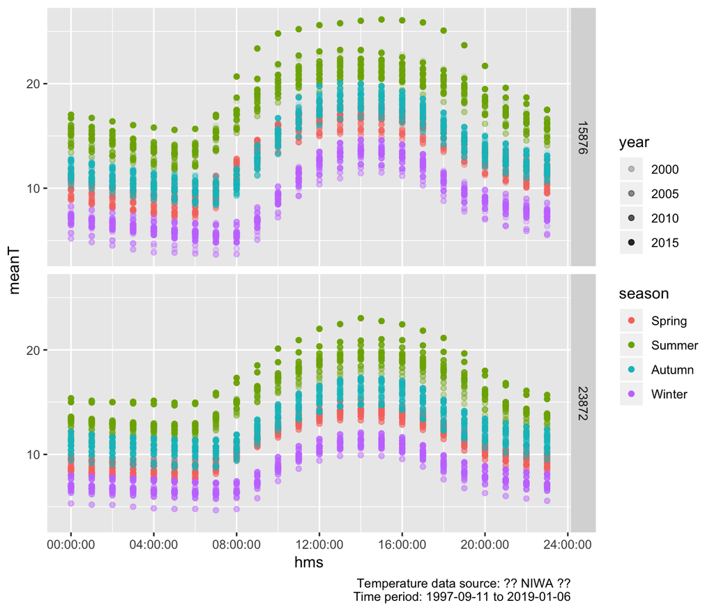

Figure 2.5: Line plot of mean temperature by season and location

```r
plotDT <- tempDT[, .(meanT = mean(meanTemp, na.rm = TRUE)), # crucial otherwise any NA causes the calculation to be NA
                 keyby = .(hms, season, Station, year)]

tempCap <- paste0("Temperature data source: ?? NIWA ??",
                        "\n Time period: ", min(lubridate::date(tempDT$r_dateTimeLocal), na.rm = TRUE),
                        " to ",
                         max(lubridate::date(tempDT$r_dateTimeLocal), na.rm = TRUE)
                  )

ggplot2::ggplot(plotDT, aes(x = hms, y = meanT, colour = season, alpha = year)) +
  geom_point() +
  facet_grid(Station ~ .) +
  labs(caption = tempCap)
```

### 2.2.2 1 file

Now test the single temperature file which contains both.

```r
message("Loading alltemp_hourly.csv.gz")
```

```
## Loading alltemp_hourly.csv.gz
```

```r
tempBothDT <- data.table::fread(paste0(myParams$dPath, "alltemp_hourly.csv.gz"))

kableExtra::kable(head(tempBothDT),
                  caption = "Head:  alltemp_hourly.csv.gz before processing")
```

Table 2.8: Head: alltemp_hourly.csv.gz before processing

| V1 | location | r_dateTime | Tmax_C | Tmin_C | Tmean_C | location |
| --- | --- | --- | --- | --- | --- | --- |
| 1 | 15876 | 1997-09-11 17:00:00 | 14.4 | 13.8 | 14.2 | 15876 |
| 2 | 15876 | 1997-09-11 18:00:00 | 14.3 | 12.8 | 13.8 | 15876 |
| 3 | 15876 | 1997-09-11 19:00:00 | 12.9 | 12.1 | 12.5 | 15876 |
| 4 | 15876 | 1997-09-11 20:00:00 | 12.4 | 11.9 | 12.2 | 15876 |
| 5 | 15876 | 1997-09-11 21:00:00 | 11.9 | 11.0 | 11.5 | 15876 |
| 6 | 15876 | 1997-09-11 22:00:00 | 11.7 | 11.1 | 11.4 | 15876 |

```r
tempBothDT <- tempBothDT[, r_dateTimeLocal := lubridate::ymd_hms(r_dateTime, # looks like NZT as the first rows it match the first few rows of temp15876DT
                                                  tz = "Pacific/Auckland")] # just to be sure (if you ran this code in the UK it would set it to UTC by default)


  tempBothDT <- tempBothDT[, hms := hms::as.hms(r_dateTimeLocal)]

  tempBothDT <- GREENGridData::addNZSeason(tempBothDT)

skimr::skim(tempBothDT)
```

```
## Skim summary statistics
##  n obs: 324465
##  n variables: 10
##
## ── Variable type:character ───────────────────────────────────────────────────────────────────────────────────────────────────────────
##    variable missing complete      n min max empty n_unique
##  r_dateTime      37   324428 324465  19  19     0   186732
##
## ── Variable type:difftime ────────────────────────────────────────────────────────────────────────────────────────────────────────────
##  variable missing complete      n    min        max     median n_unique
##       hms      37   324428 324465 0 secs 82800 secs 43200 secs       24
##
## ── Variable type:factor ──────────────────────────────────────────────────────────────────────────────────────────────────────────────
##  variable missing complete      n n_unique
##    season       0   324465 324465        4
##                                      top_counts ordered
##  Spr: 81672, Win: 81298, Sum: 81200, Aut: 80295   FALSE
##
## ── Variable type:integer ─────────────────────────────────────────────────────────────────────────────────────────────────────────────
##    variable missing complete      n      mean       sd    p0   p25    p50
##    location       0   324465 324465  19301.71  3956.83 15876 15876  15876
##  location.1       0   324465 324465  19301.71  3956.83 15876 15876  15876
##          V1       0   324465 324465 162233    93665.12     1 81117 162233
##     p75   p100     hist
##   23872  23872 ▇▁▁▁▁▁▁▆
##   23872  23872 ▇▁▁▁▁▁▁▆
##  243349 324465 ▇▇▇▇▇▇▇▇
##
## ── Variable type:numeric ─────────────────────────────────────────────────────────────────────────────────────────────────────────────
##  variable missing complete      n  mean   sd    p0 p25  p50  p75 p100
##    Tmax_C     503   323962 324465 13.26 5.33  -9.5 9.7 13.2 16.9 36.4
##   Tmean_C     634   323831 324465 12.63 5.3  -10   9.1 12.6 16.3 35.6
##    Tmin_C     577   323888 324465 12.02 5.29 -12.2 8.5 12   15.7 34.2
##      hist
##  ▁▁▃▇▇▃▁▁
##  ▁▁▃▇▇▂▁▁
##  ▁▁▂▇▇▃▁▁
##
## ── Variable type:POSIXct ─────────────────────────────────────────────────────────────────────────────────────────────────────────────
##         variable missing complete      n        min        max     median
##  r_dateTimeLocal      37   324428 324465 1997-09-11 2019-01-06 2009-08-24
##  n_unique
##    186732
```

```r
tempBothDT$V1 <- NULL
tempBothDT <- tempBothDT[, meanTemp := Tmean_C]


kableExtra::kable(head(tempBothDT),
                  caption = "Head:  alltemp_hourly.csv.gz after processing")
```

Table 2.8: Head: alltemp_hourly.csv.gz after processing

| location | r_dateTime | Tmax_C | Tmin_C | Tmean_C | location | r_dateTimeLocal | hms | season | meanTemp |
| --- | --- | --- | --- | --- | --- | --- | --- | --- | --- |
| 15876 | 1997-09-11 17:00:00 | 14.4 | 13.8 | 14.2 | 15876 | 1997-09-11 17:00:00 | 17:00:00 | Spring | 14.2 |
| 15876 | 1997-09-11 18:00:00 | 14.3 | 12.8 | 13.8 | 15876 | 1997-09-11 18:00:00 | 18:00:00 | Spring | 13.8 |
| 15876 | 1997-09-11 19:00:00 | 12.9 | 12.1 | 12.5 | 15876 | 1997-09-11 19:00:00 | 19:00:00 | Spring | 12.5 |
| 15876 | 1997-09-11 20:00:00 | 12.4 | 11.9 | 12.2 | 15876 | 1997-09-11 20:00:00 | 20:00:00 | Spring | 12.2 |
| 15876 | 1997-09-11 21:00:00 | 11.9 | 11.0 | 11.5 | 15876 | 1997-09-11 21:00:00 | 21:00:00 | Spring | 11.5 |
| 15876 | 1997-09-11 22:00:00 | 11.7 | 11.1 | 11.4 | 15876 | 1997-09-11 22:00:00 | 22:00:00 | Spring | 11.4 |

Figure 2.6 shows the mean temperature by time of day by season for the data from . Does this look right? The alpha values are suggesting it’s getting warmer…

Again, this plot tells us if our dateTime assumptions are correct.

```r
# combine the temperature data

message("Note that ", nrow(tempBothDT[is.na(meanTemp)]), " observations have no Tmean(C) values...")
```

```
## Note that 634 observations have no Tmean(C) values...
```

```r
tempBothDT <- tempBothDT[, year := lubridate::year(r_dateTime)]
t <- addmargins(with(tempBothDT[is.na(meanTemp)], table(location,year)))

kableExtra::kable(t, caption = "Counts of missing temperature observations by location and year (source: 1 file)") %>%
  kable_styling()
```

Table 2.9: Counts of missing temperature observations by location and year (source: 1 file)

|  | 1998 | 2003 | 2004 | 2006 | 2007 | 2008 | 2010 | 2012 | 2014 | 2015 | 2016 | 2018 | Sum |
| --- | --- | --- | --- | --- | --- | --- | --- | --- | --- | --- | --- | --- | --- |
| 15876 | 2 | 53 | 491 | 0 | 0 | 1 | 0 | 1 | 0 | 0 | 3 | 0 | 551 |
| 23872 | 0 | 0 | 0 | 12 | 11 | 0 | 31 | 1 | 1 | 1 | 0 | 26 | 83 |
| Sum | 2 | 53 | 491 | 12 | 11 | 1 | 31 | 2 | 1 | 1 | 3 | 26 | 634 |

```r
message("But it's mostly in years we don't have HP data for?")
```

```
## But it's mostly in years we don't have HP data for?
```

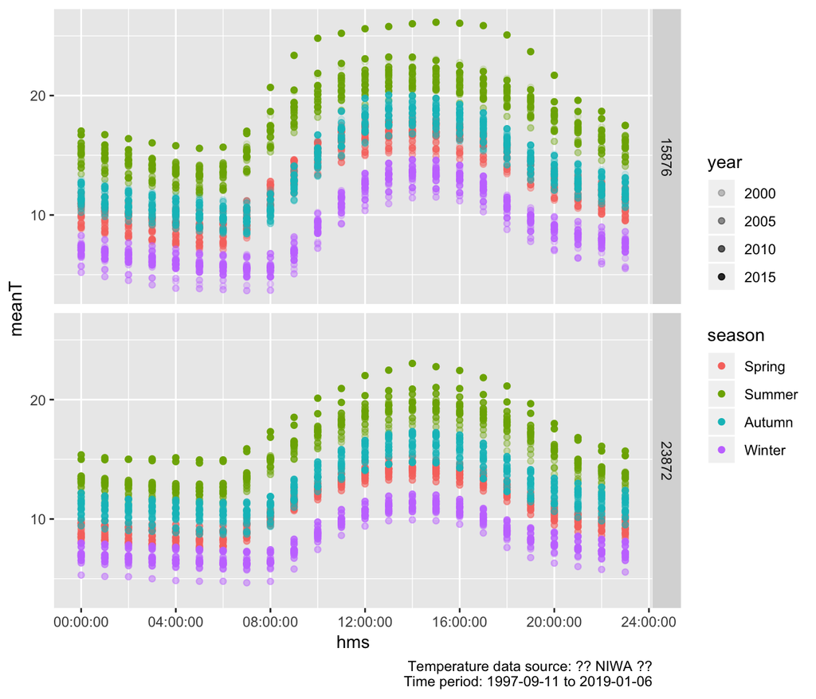

Figure 2.6: Line plot of mean temperature by season and location

```r
plotDT <- tempBothDT[, .(meanT = mean(meanTemp, na.rm = TRUE)), # crucial otherwise any NA causes the calculation to be NA
                 keyby = .(hms, season, location, year)]

tempCap <- paste0("Temperature data source: ?? NIWA ??",
                        "\n Time period: ", min(lubridate::date(tempBothDT$r_dateTimeLocal), na.rm = TRUE),
                        " to ",
                         max(lubridate::date(tempBothDT$r_dateTimeLocal), na.rm = TRUE)
                  )

ggplot2::ggplot(plotDT, aes(x = hms, y = meanT, colour = season, alpha = year)) +
  geom_point() +
  facet_grid(location ~ .) +
  labs(caption = tempCap)
```

Now we can directly compare the two sources of temperature data to see if they match. Figure 2.7 does this by linking the two files on `r_dateTimeLocal` and `location` and then plotting the temperature values from each source.

```r
message("N rows of 2 files merged: ", nrow(tempDT))
```

```
## N rows of 2 files merged: 328719
```

```r
message("N rows of alltemp_hourly.csv.gz : ", nrow(tempBothDT))
```

```
## N rows of alltemp_hourly.csv.gz : 324465
```

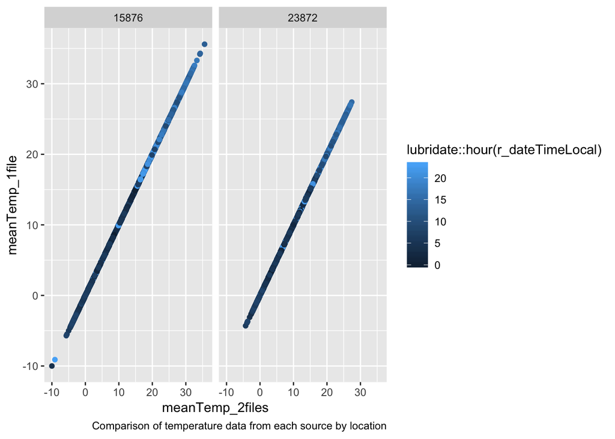

Figure 2.7: Comparison of temperature data from each source by location

```r
tempDT <- tempDT[, `:=`(source, "Separate files")]
tempBothDT <- tempBothDT[, `:=`(source, "alltemp_hourly.csv.gz")]

# let's try just comparing dates

t2fdt <- tempDT[, .(dateTime_char_2f = `Date(NZST)`, r_dateTimeLocal, meanTemp_2files = meanTemp,
    location, hms_2files = hms)]
setkey(t2fdt, r_dateTimeLocal, location)

t1fdt <- tempBothDT[, .(dateTime_char_1f = r_dateTime, r_dateTimeLocal, meanTemp_1file = meanTemp,
    location, hms_1file = hms)]
setkey(t1fdt, r_dateTimeLocal, location)

dt <- t2fdt[t1fdt]  # merge on dateTimeLocal & location

ggplot2::ggplot(dt[!is.na(r_dateTimeLocal)], aes(x = meanTemp_2files, y = meanTemp_1file,
    colour = lubridate::hour(r_dateTimeLocal))) + geom_point() + facet_grid(. ~
    location) + labs(caption = "Comparison of temperature data from each source by location")
```

```r
# so some of them match but not all
dt <- dt[, `:=`(diffTemp, meanTemp_2files - meanTemp_1file)]
```

## 2.3 Link the HP and temperature data

So it looks like the date times are OK for both the HP and temperature data and either version of the temperature data is OK too. Now let’s try to link the temperature data derivd from the 2 files to the heat pump data using station and r_dateTimeLocal.

```r
tempDT <- data.table::setkey(tempDT, location, r_dateTimeLocal)  # set key to link
tempDT <- tempDT[, `:=`(hour, lubridate::hour(r_dateTimeLocal))]

hpDT <- data.table::setkey(hpDT, location, r_dateTimeLocal)
hpDT <- hpDT[, `:=`(hour, lubridate::hour(r_dateTimeLocal))]

# remove the NA dateTimes before we do
tempDTclean <- tempDT[!is.na(r_dateTimeLocal)]

linkedDT <- tempDTclean[hpDT]  # this will add each row of tempDT to the end of each relevant row of hpDT
```

Now, because we did *not* match on `hour` we can see if anything failed to match up in terms of time of day. There are (Table 2.10) but it looks like they are to do with the missing temperature data as the NAs in the temperature columns (see Table 2.11).

```r
t <- addmargins(with(linkedDT, table(hour, i.hour, useNA = "always")))

kableExtra::kable(t, caption = "Counts of hours from each source") %>% kable_styling()
```

Table 2.10: Counts of hours from each source

|  | 0 | 1 | 2 | 3 | 4 | 5 | 6 | 7 | 8 | 9 | 10 | 11 | 12 | 13 | 14 | 15 | 16 | 17 | 18 | 19 | 20 | 21 | 22 | 23 | NA | Sum |
| --- | --- | --- | --- | --- | --- | --- | --- | --- | --- | --- | --- | --- | --- | --- | --- | --- | --- | --- | --- | --- | --- | --- | --- | --- | --- | --- |
| 0 | 18180 | 0 | 0 | 0 | 0 | 0 | 0 | 0 | 0 | 0 | 0 | 0 | 0 | 0 | 0 | 0 | 0 | 0 | 0 | 0 | 0 | 0 | 0 | 0 | 0 | 18180 |
| 1 | 0 | 18183 | 0 | 0 | 0 | 0 | 0 | 0 | 0 | 0 | 0 | 0 | 0 | 0 | 0 | 0 | 0 | 0 | 0 | 0 | 0 | 0 | 0 | 0 | 0 | 18183 |
| 2 | 0 | 0 | 18133 | 0 | 0 | 0 | 0 | 0 | 0 | 0 | 0 | 0 | 0 | 0 | 0 | 0 | 0 | 0 | 0 | 0 | 0 | 0 | 0 | 0 | 0 | 18133 |
| 3 | 0 | 0 | 0 | 18127 | 0 | 0 | 0 | 0 | 0 | 0 | 0 | 0 | 0 | 0 | 0 | 0 | 0 | 0 | 0 | 0 | 0 | 0 | 0 | 0 | 0 | 18127 |
| 4 | 0 | 0 | 0 | 0 | 18177 | 0 | 0 | 0 | 0 | 0 | 0 | 0 | 0 | 0 | 0 | 0 | 0 | 0 | 0 | 0 | 0 | 0 | 0 | 0 | 0 | 18177 |
| 5 | 0 | 0 | 0 | 0 | 0 | 18188 | 0 | 0 | 0 | 0 | 0 | 0 | 0 | 0 | 0 | 0 | 0 | 0 | 0 | 0 | 0 | 0 | 0 | 0 | 0 | 18188 |
| 6 | 0 | 0 | 0 | 0 | 0 | 0 | 18186 | 0 | 0 | 0 | 0 | 0 | 0 | 0 | 0 | 0 | 0 | 0 | 0 | 0 | 0 | 0 | 0 | 0 | 0 | 18186 |
| 7 | 0 | 0 | 0 | 0 | 0 | 0 | 0 | 18198 | 0 | 0 | 0 | 0 | 0 | 0 | 0 | 0 | 0 | 0 | 0 | 0 | 0 | 0 | 0 | 0 | 0 | 18198 |
| 8 | 0 | 0 | 0 | 0 | 0 | 0 | 0 | 0 | 18203 | 0 | 0 | 0 | 0 | 0 | 0 | 0 | 0 | 0 | 0 | 0 | 0 | 0 | 0 | 0 | 0 | 18203 |
| 9 | 0 | 0 | 0 | 0 | 0 | 0 | 0 | 0 | 0 | 18179 | 0 | 0 | 0 | 0 | 0 | 0 | 0 | 0 | 0 | 0 | 0 | 0 | 0 | 0 | 0 | 18179 |
| 10 | 0 | 0 | 0 | 0 | 0 | 0 | 0 | 0 | 0 | 0 | 18194 | 0 | 0 | 0 | 0 | 0 | 0 | 0 | 0 | 0 | 0 | 0 | 0 | 0 | 0 | 18194 |
| 11 | 0 | 0 | 0 | 0 | 0 | 0 | 0 | 0 | 0 | 0 | 0 | 18158 | 0 | 0 | 0 | 0 | 0 | 0 | 0 | 0 | 0 | 0 | 0 | 0 | 0 | 18158 |
| 12 | 0 | 0 | 0 | 0 | 0 | 0 | 0 | 0 | 0 | 0 | 0 | 0 | 18171 | 0 | 0 | 0 | 0 | 0 | 0 | 0 | 0 | 0 | 0 | 0 | 0 | 18171 |
| 13 | 0 | 0 | 0 | 0 | 0 | 0 | 0 | 0 | 0 | 0 | 0 | 0 | 0 | 18186 | 0 | 0 | 0 | 0 | 0 | 0 | 0 | 0 | 0 | 0 | 0 | 18186 |
| 14 | 0 | 0 | 0 | 0 | 0 | 0 | 0 | 0 | 0 | 0 | 0 | 0 | 0 | 0 | 18193 | 0 | 0 | 0 | 0 | 0 | 0 | 0 | 0 | 0 | 0 | 18193 |
| 15 | 0 | 0 | 0 | 0 | 0 | 0 | 0 | 0 | 0 | 0 | 0 | 0 | 0 | 0 | 0 | 18207 | 0 | 0 | 0 | 0 | 0 | 0 | 0 | 0 | 0 | 18207 |
| 16 | 0 | 0 | 0 | 0 | 0 | 0 | 0 | 0 | 0 | 0 | 0 | 0 | 0 | 0 | 0 | 0 | 18220 | 0 | 0 | 0 | 0 | 0 | 0 | 0 | 0 | 18220 |
| 17 | 0 | 0 | 0 | 0 | 0 | 0 | 0 | 0 | 0 | 0 | 0 | 0 | 0 | 0 | 0 | 0 | 0 | 18233 | 0 | 0 | 0 | 0 | 0 | 0 | 0 | 18233 |
| 18 | 0 | 0 | 0 | 0 | 0 | 0 | 0 | 0 | 0 | 0 | 0 | 0 | 0 | 0 | 0 | 0 | 0 | 0 | 18234 | 0 | 0 | 0 | 0 | 0 | 0 | 18234 |
| 19 | 0 | 0 | 0 | 0 | 0 | 0 | 0 | 0 | 0 | 0 | 0 | 0 | 0 | 0 | 0 | 0 | 0 | 0 | 0 | 18235 | 0 | 0 | 0 | 0 | 0 | 18235 |
| 20 | 0 | 0 | 0 | 0 | 0 | 0 | 0 | 0 | 0 | 0 | 0 | 0 | 0 | 0 | 0 | 0 | 0 | 0 | 0 | 0 | 18229 | 0 | 0 | 0 | 0 | 18229 |
| 21 | 0 | 0 | 0 | 0 | 0 | 0 | 0 | 0 | 0 | 0 | 0 | 0 | 0 | 0 | 0 | 0 | 0 | 0 | 0 | 0 | 0 | 18227 | 0 | 0 | 0 | 18227 |
| 22 | 0 | 0 | 0 | 0 | 0 | 0 | 0 | 0 | 0 | 0 | 0 | 0 | 0 | 0 | 0 | 0 | 0 | 0 | 0 | 0 | 0 | 0 | 18209 | 0 | 0 | 18209 |
| 23 | 0 | 0 | 0 | 0 | 0 | 0 | 0 | 0 | 0 | 0 | 0 | 0 | 0 | 0 | 0 | 0 | 0 | 0 | 0 | 0 | 0 | 0 | 0 | 18141 | 0 | 18141 |
| NA | 192 | 198 | 244 | 198 | 198 | 198 | 211 | 200 | 197 | 221 | 209 | 228 | 219 | 209 | 204 | 191 | 184 | 184 | 184 | 188 | 187 | 187 | 185 | 189 | 0 | 4805 |
| Sum | 18372 | 18381 | 18377 | 18325 | 18375 | 18386 | 18397 | 18398 | 18400 | 18400 | 18403 | 18386 | 18390 | 18395 | 18397 | 18398 | 18404 | 18417 | 18418 | 18423 | 18416 | 18414 | 18394 | 18330 | 0 | 441396 |

```r
t <- head(linkedDT[is.na(hour)])
kableExtra::kable(t, caption = "Rows of data where hour (fromtemperature data file) = NA") %>%
    kable_styling()
```

Table 2.11: Rows of data where hour (fromtemperature data file) = NA

| Station | Date(NZST) | Tmax(C) | Period(Hrs) | Period(Hrs).1 | Period(Hrs).2 | Period(Hrs).3 | Tmin(C) | Tgmin(C) | Tmean(C) | RHmean(%) | Freq | r_dateTime | hms | season | r_dateTimeLocal | location | meanTemp | year | source | hour | i.r_dateTime | powerW | circuit | id | r_dateTimeChar | i.hms | i.season | includeCircuit | i.hour |
| --- | --- | --- | --- | --- | --- | --- | --- | --- | --- | --- | --- | --- | --- | --- | --- | --- | --- | --- | --- | --- | --- | --- | --- | --- | --- | --- | --- | --- | --- |
| NA | NA | NA | NA | NA | NA | NA | NA | NA | NA | NA | NA | NA | NA | NA | 2015-04-05 02:00:00 | 15876 | NA | NA | NA | NA | 2015-04-04 13:00:00 | 0.00000 | Heat Pump$4204 | rf_31 | 2015-04-04 13:00:00 | 02:00:00 | Autumn | 1 | 2 |
| NA | NA | NA | NA | NA | NA | NA | NA | NA | NA | NA | NA | NA | NA | NA | 2015-04-05 02:00:00 | 15876 | NA | NA | NA | NA | 2015-04-04 13:00:00 | 0.00000 | Heat Pump$4223 | rf_34 | 2015-04-04 13:00:00 | 02:00:00 | Autumn | 1 | 2 |
| NA | NA | NA | NA | NA | NA | NA | NA | NA | NA | NA | NA | NA | NA | NA | 2015-04-05 02:00:00 | 15876 | NA | NA | NA | NA | 2015-04-04 13:00:00 | 0.20000 | Heat Pump$4124 | rf_35 | 2015-04-04 13:00:00 | 02:00:00 | Autumn | 1 | 2 |
| NA | NA | NA | NA | NA | NA | NA | NA | NA | NA | NA | NA | NA | NA | NA | 2015-04-05 02:00:00 | 15876 | NA | NA | NA | NA | 2015-04-04 13:00:00 | 0.00000 | Heat Pump$4154 | rf_44 | 2015-04-04 13:00:00 | 02:00:00 | Autumn | 1 | 2 |
| NA | NA | NA | NA | NA | NA | NA | NA | NA | NA | NA | NA | NA | NA | NA | 2015-05-29 09:00:00 | 15876 | NA | NA | NA | NA | 2015-05-28 21:00:00 | 225.59650 | Heat Pump$4204 | rf_31 | 2015-05-28 21:00:00 | 09:00:00 | Autumn | 1 | 9 |
| NA | NA | NA | NA | NA | NA | NA | NA | NA | NA | NA | NA | NA | NA | NA | 2015-05-29 09:00:00 | 15876 | NA | NA | NA | NA | 2015-05-28 21:00:00 | 31.88967 | Heat Pump$4196 | rf_32 | 2015-05-28 21:00:00 | 09:00:00 | Autumn | 1 | 9 |

# 3 Test relationship between temperature and heat pump demand

So now we think we’ve linked the data correctly, let’s do some exploratory analysis. Following Emily’s suggestion we only keep heat pump data where power > 40 and for the circuits we wish to include.

First we just plot all the hourly data for demand vs mean temperature (Figure 3.1).

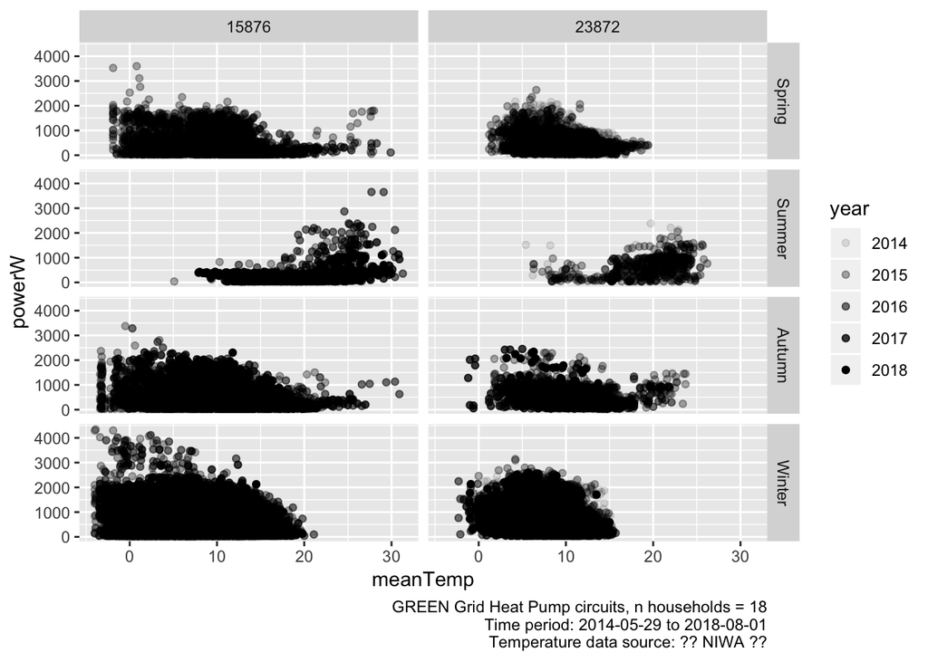

Figure 3.1: Plots of temperature vs demand by season and location

```r
dt <- linkedDT[powerW > 40 & includeCircuit == 1 & !is.na(meanTemp)]

tempCap <- paste0("Temperature data source: ?? NIWA ??")

combinedCaption <- paste0(hpCap, "\n", tempCap)

ggplot2::ggplot(dt, aes(x = meanTemp, y = powerW, alpha = year)) + geom_point() +
    facet_grid(season ~ location) + labs(caption = paste0(combinedCaption))
```

That doesn’t tell us a lot - although these is indeed a suggestion of their use for cooling in summer in both locations. So let’s try to create the binned box plots.

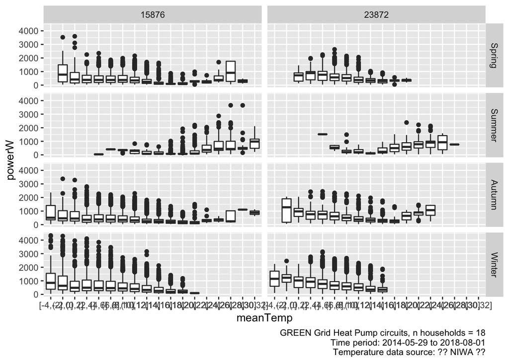

Figure 3.2: Box plots of temperature vs demand by season and location

```r
dt <- linkedDT[powerW > 40 & includeCircuit == 1 & !is.na(meanTemp)]

ggplot2::ggplot(dt, mapping = aes(x = meanTemp, y = powerW)) +
  geom_boxplot(aes(cut_width(meanTemp,
                             width = 2, # change the width to get 'wider' bins
                             boundary = 0)))  +
  facet_grid(season ~ location) +
  labs(caption = combinedCaption)
```

Figure 3.2 shows binned box plots of power against demand and suggest more clearly that there is a cooling effect for households in summer - especially in 15876. Or perhaps we should more accurately say there is evidence of a summer cooling effect in the 11 (!) households who live in 15876. And who would base a claim on that many households?

Anyway, just for good measure lets try to re-create the U shaped plots Emily produced by ignoring season.

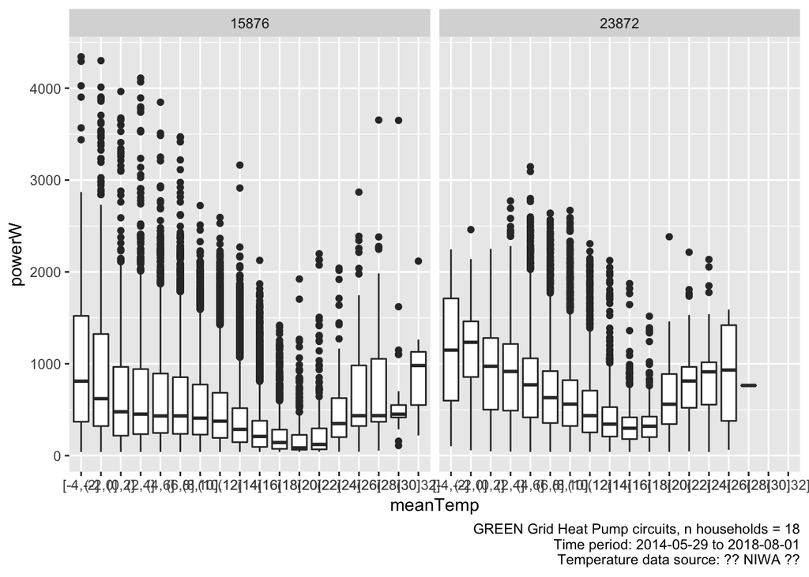

```r
dt <- linkedDT[powerW > 40 & includeCircuit == 1 & !is.na(meanTemp)]

ggplot2::ggplot(dt, mapping = aes(x = meanTemp, y = powerW)) +
  geom_boxplot(aes(cut_width(meanTemp,
                             width = 2, # change the width to get 'wider' bins
                             boundary = 0)))  +
  facet_grid(. ~ location) +
  labs(caption = combinedCaption)
```

Yep, can see it!

> If this still does not look right then the only thing left to worry about is whether the heat pump data is actually stored in NZ time - although our profiles suggest it is not.

# 4 Runtime

```r
t <- proc.time() - startTime

elapsed <- t[[3]]
```

Analysis completed in 94.803 seconds ( 1.58 minutes) using knitr in [RStudio](http://www.rstudio.com) with R version 3.5.2 (2018-12-20) running on x86_64-apple-darwin15.6.0.

# 5 R packages used

> list packages used & cite

# 6 References